# US Flights 2018 Dataset

## OP_CARRIER Flights Percentage

- We can conclude that Southwest Airlines is the largest number of flights in 2018 by 18% of the total flights and we can explore that Delta Airlines, American Airlines, SkyWest Airlines, United Airlines took about 45% of flights. Therefore, we can see that Top 5 Airlines carriers took about 63% of US flights in 2018. Then we will focus on Top 5 in later analysis.

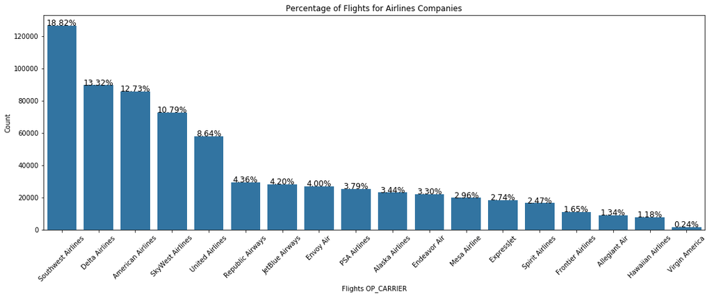

```python
# univariate plots of OP_CARRIER

DEP_order = flights['OP_CARRIER_NAME'].value_counts().index
base_color = sb.color_palette()[0]
sb.countplot(data=flights, x='OP_CARRIER_NAME', color=base_color, order=DEP_order);
plt.xticks(rotation=0);
# Recalculating the cut_counts
DEP_DELAY_counts = flights['OP_CARRIER_NAME'].value_counts()
# Returns the sum of all not-null values in `cut` column
n_flights = flights['OP_CARRIER_NAME'].value_counts().sum()
# get the current tick locations and labels
locs, labels = plt.xticks(rotation=45)

# loop through each pair of locations and labels
for loc, label in zip(locs, labels):

    # get the text property for the label to get the correct count
    count = DEP_DELAY_counts[label.get_text()]
    pct_string = '{:0.2f}%'.format(100*count/n_flights)

    # print the annotation just below the top of the bar
    plt.text(loc, count+2, pct_string, ha = 'center', color = 'black',fontsize=12, verticalalignment='baseline')
plt.xlabel('Flights OP_CARRIER');
plt.ylabel('Count');
plt.title("Percentage of Flights for Airlines Companies");
from matplotlib import rcParams
# Specify the figure size in inches, for both X, and Y axes
rcParams['figure.figsize'] =16,6
```

# ARRIVAL DELAY & DEPARTURE DELAY Relationship

> - We can find that linear relationship and postive correlation and also we can conclude that very small delays are the most affected for the majority of flights as we see the high density color(600,000 flights) around zero.

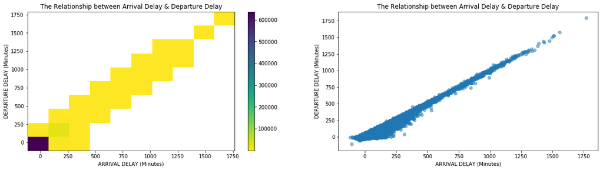

```python
# Scatter plot by MAtplotlib
#bins_x=np.arange(0.6,7+0.3,0.3)
#bins_y=np.arange(92,692+50,50)
# Resize figure to accommodate two plots
plt.figure(figsize = [20, 5])
plt.subplot(1, 2, 1)
#plt.scatter(data = flights, x='displ', y='co2', alpha=0.5);
plt.hist2d(data = flights, x='ARR_DELAY', y='DEP_DELAY', cmin=0.5, cmap='viridis_r');
plt.colorbar()
plt.xlabel('ARRIVAL DELAY (Minutes)')
plt.ylabel('DEPARTURE DELAY (Minutes)');
plt.title("The Relationship between Arrival Delay & Departure Delay");
plt.subplot(1, 2, 2)
# Scatter plot by Seaborn library
sb.regplot(data = flights, x='ARR_DELAY', y='DEP_DELAY', fit_reg=False, truncate=True, x_jitter=0, scatter_kws={'alpha':1/2})
plt.xlabel('ARRIVAL DELAY (Minutes)')
plt.ylabel('DEPARTURE DELAY (Minutes)');
plt.title("The Relationship between Arrival Delay & Departure Delay");
```